# Конфирматорный факторный анализ

```r
library(tidyr)
library(dplyr)
library(magrittr)
library(sjmisc)
library(ggplot2)
library(haven)
full_ess <- haven::read_sav("ESS7e02_1.sav")
```

Подключаем основные необходимые пакеты и загружаем полный набор данных.

```r
countries <- unique(full_ess$cntry)
print(countries)
```

```
 [1] "AT" "BE" "CH" "CZ" "DE" "DK" "EE" "ES" "FI" "FR" "GB" "HU" "IE" "IL" "LT" "NL" "NO" "PL" "PT" "SE" "SI"
```

Выводим коды стран. Нам понадобится код Венгрии.

```r
HU.values <- full_ess %>% filter(cntry=="HU") %>%
  dplyr::select("fltdpr", "flteeff", "slprl",
                "wrhpp", "fltlnl", "enjlf",
                "fltsd", "cldgng") %>%
  set_colnames(c("depressed", "everything_as_effort",
                 "restless_sleep", "happy",
                 "lonely", "enjoyed_life",
                 "sad", "could_not_get_going"))  %>%
  na.omit
save(HU.values, file="HU.values.R")
```

Выбираем из полного набора данных часть, с которой будем работать (Венгрия, шкала настроения E20-E27). Даем переменным удобные для интерпретации названия.

Вначале проводим разведывательный факторный анализ.

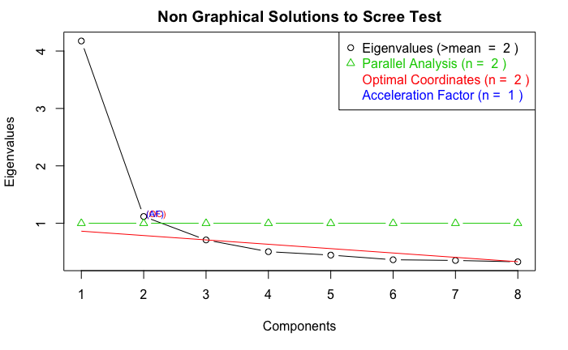

```r
library(nFactors)
plot(nScree(cov(HU.values)))
```

Определяем число факторов. Большинство критериев предлагает выбрать число факторов равным 2. Для сравнения также построим также модели с 1 и 3 факторами.

```r
library("GPArotation")
formulaEFA <- as.formula("~depressed + everything_as_effort + restless_sleep + happy + lonely + enjoyed_life + sad + could_not_get_going")
EFA1 <- factanal(formulaEFA, factors=1, data=HU.values,
                 #rotation = "geominQ",
                 na.action=na.exclude)
EFA1
```

```
Call:
factanal(x = formulaEFA, factors = 1, data = HU.values, na.action = na.exclude)

Uniquenesses:
           depressed everything_as_effort       restless_sleep
               0.431                0.444                0.594
               happy               lonely         enjoyed_life
               0.714                0.653                0.663
                 sad  could_not_get_going
               0.445                0.409

Loadings:
                     Factor1
depressed             0.754
everything_as_effort  0.746
restless_sleep        0.637
happy                -0.535
lonely                0.589
enjoyed_life         -0.581
sad                   0.745
could_not_get_going   0.769

               Factor1
SS loadings      3.646
Proportion Var   0.456

Test of the hypothesis that 1 factor is sufficient.
The chi square statistic is 883.9 on 20 degrees of freedom.
The p-value is 2.09e-174
```

Строим модель с 1 фактором.

```r
EFA2 <- factanal(formulaEFA, factors=2, data=HU.values,
                 #rotation = "geominQ",
                 na.action=na.exclude)
EFA2
```

```
Call:
factanal(x = formulaEFA, factors = 2, data = HU.values, na.action = na.exclude)

Uniquenesses:
           depressed everything_as_effort       restless_sleep
               0.381                0.338                0.519
               happy               lonely         enjoyed_life
               0.373                0.640                0.375
                 sad  could_not_get_going
               0.480                0.441

Loadings:
                     Factor1 Factor2
depressed             0.739   0.270
everything_as_effort  0.788   0.200
restless_sleep        0.677   0.150
happy                -0.180  -0.771
lonely                0.391   0.455
enjoyed_life         -0.247  -0.751
sad                   0.587   0.419
could_not_get_going   0.642   0.384

               Factor1 Factor2
SS loadings      2.629   1.825
Proportion Var   0.329   0.228
Cumulative Var   0.329   0.557

Test of the hypothesis that 2 factors are sufficient.
The chi square statistic is 216.2 on 13 degrees of freedom.
The p-value is 6.21e-39
```

C 2 факторами.

```r
EFA3 <- factanal(formulaEFA, factors=3, data=HU.values,
                 #rotation = "geominQ",
                 na.action=na.exclude)
EFA3
```

```
Call:
factanal(x = formulaEFA, factors = 3, data = HU.values, na.action = na.exclude)

Uniquenesses:
           depressed everything_as_effort       restless_sleep
               0.375                0.294                0.508
               happy               lonely         enjoyed_life
               0.373                0.590                0.340
                 sad  could_not_get_going
               0.273                0.410

Loadings:
                     Factor1 Factor2 Factor3
depressed             0.696  -0.242   0.288
everything_as_effort  0.782  -0.176   0.251
restless_sleep        0.655  -0.139   0.210
happy                -0.155   0.745  -0.219
lonely                0.235  -0.348   0.484
enjoyed_life         -0.216   0.751  -0.223
sad                   0.364  -0.252   0.728
could_not_get_going   0.490  -0.273   0.525

               Factor1 Factor2 Factor3
SS loadings      2.023   1.487   1.328
Proportion Var   0.253   0.186   0.166
Cumulative Var   0.253   0.439   0.605

Test of the hypothesis that 3 factors are sufficient.
The chi square statistic is 6.75 on 7 degrees of freedom.
The p-value is 0.456
```

И с 3 факторами.

```r
print(c('1 factor', round(unname(EFA1$STATISTIC), 3), EFA1$dof, round(unname(EFA1$PVAL), 3)), digits = 3)
```

```
[1] "1 factor" "883.909"  "20"       "0"
```

```r
print(c('2 factors', round(unname(EFA2$STATISTIC), 3), EFA2$dof, round(unname(EFA2$PVAL), 3)), digits = 3)
```

```
[1] "2 factors" "216.243"   "13"        "0"
```

```r
print(c('3 factors', round(unname(EFA3$STATISTIC), 3), EFA3$dof, round(unname(EFA3$PVAL), 3)), digits = 3)
```

```
[1] "3 factors" "6.748"     "7"         "0.456"
```

Так как модели с разным количеством факторов являются вложенными, мы можем сравнить их критерием хи-квадрат. Выведем значения статистики хи-квадрат, число степеней свободы и p-значение теста на значимость хи-квадрата модели для моделей с 1, 2 и 3 факторами. Уже по p-значениям мы можем видеть (они близки к нулю, нулевая гипотеза о корректном представлении факторами исходных данных отвергается), что для 1 и 2 фактора не позволяют хорошо описать исследуемые признаки, необходимо большее число факторов.

```r
chisq.difference_1_2 = unname(EFA1$STATISTIC) - unname(EFA2$STATISTIC)
df.difference_1_2 = EFA1$dof - EFA2$dof
1-pchisq(chisq.difference_1_2, df.difference_1_2)
```

```
[1] 0
```

Cравним модели с 1 и 2 факторами с помощью теста хи-квадрат. В данном случае p-значение очень мало и разница в значениях статистик хи-квадрат значима, модель с 2 факторами лучше.

```r
chisq.difference_2_3 = unname(EFA2$STATISTIC) - unname(EFA3$STATISTIC)
df.difference_2_3 = EFA2$dof - EFA3$dof
1-pchisq(chisq.difference_2_3, df.difference_2_3)
```

```
[1] 0
```

Аналогичным образом сравним модели с 2 и 3 факторами. Согласно критерию хи-квадрат модель с 3 факторами лучше модели с 2 факторами, выберем ее.

```r
EFA3<- factanal(formulaEFA, factors=3, data=HU.values, rotation = "geominQ")
load3 <- as.data.frame.matrix(EFA3$loadings)
round(load3,2)
```

|  | Factor1 | Factor2 | Factor3 |
| --- | --- | --- | --- |
| depressed | 0.71 | -0.06 | 0.06 |
| everything_as_effort | 0.85 | 0.02 | -0.01 |
| restless_sleep | 0.72 | 0.02 | 0.00 |
| happy | 0.02 | 0.79 | -0.02 |
| lonely | -0.02 | -0.19 | 0.52 |
| enjoyed_life | -0.06 | 0.78 | 0.00 |
| sad | 0.02 | 0.04 | 0.86 |
| could_not_get_going | 0.30 | -0.04 | 0.50 |

Построим модель с 3 факторами с вращением факторов и выведем факторные нагрузки. Так как факторов больше 2, график выводить не будем. Второй фактор ассоциирован с счастьем и удовольствием от жизни, назовем его “Joy” (радость). Первый - беспокойством, усталостью, напряжением, подавленностью. Назовем его “Tension” (напряжение). Третий - с печалью, одиночеством, растерянностью, отсутствием жизненных сил. Назовем его “Devastation” (опустошенность).

Далее проведем конфирматорный факторный анализ для проверки сформированных выше гипотезах о трех факторах (латентных переменных).

```r
library(lavaan)
cfa3<- cfa(model="Joy =~ happy + enjoyed_life;
           Tension =~ everything_as_effort + restless_sleep + depressed;
           Devastation =~ sad + lonely + could_not_get_going",
           data=as.matrix(HU.values))
cfa3
```

```
lavaan (0.5-23.1097) converged normally after  32 iterations

  Number of observations                          1663

  Estimator                                         ML
  Minimum Function Test Statistic               96.444
  Degrees of freedom                                17
  P-value (Chi-square)                           0.000
```

Для каждого фактора первой переменной (будет иметь факторную нагрузку 1) выбираем ту, которая наиболее надежно отражает данный фактор (определяем по таблице факторных нагрузок, представленной выше).

```r
summary(cfa3, fit.measures=TRUE)
```

```
lavaan (0.5-23.1097) converged normally after  32 iterations

  Number of observations                          1663

  Estimator                                         ML
  Minimum Function Test Statistic               96.444
  Degrees of freedom                                17
  P-value (Chi-square)                           0.000

Model test baseline model:

  Minimum Function Test Statistic             5750.012
  Degrees of freedom                                28
  P-value                                        0.000

User model versus baseline model:

  Comparative Fit Index (CFI)                    0.986
  Tucker-Lewis Index (TLI)                       0.977

Loglikelihood and Information Criteria:

  Loglikelihood user model (H0)             -12565.591
  Loglikelihood unrestricted model (H1)     -12517.369

  Number of free parameters                         19
  Akaike (AIC)                               25169.183
  Bayesian (BIC)                             25272.094
  Sample-size adjusted Bayesian (BIC)        25211.734

Root Mean Square Error of Approximation:

  RMSEA                                          0.053
  90 Percent Confidence Interval          0.043  0.064
  P-value RMSEA <= 0.05                          0.297

Standardized Root Mean Square Residual:

  SRMR                                           0.028

```

[output cut: 25 more lines]

```
    Devastation       0.291    0.015   20.028    0.000

Variances:
                   Estimate  Std.Err  z-value  P(>|z|)
   .happy             0.279    0.017   16.043    0.000
   .enjoyed_life      0.219    0.020   11.140    0.000
   .evrythng_s_ffr    0.192    0.011   18.171    0.000
   .restless_sleep    0.282    0.012   24.287    0.000
   .depressed         0.189    0.010   19.279    0.000
   .sad               0.189    0.009   20.127    0.000
   .lonely            0.370    0.014   25.650    0.000
   .cold_nt_gt_gng    0.209    0.011   19.735    0.000
    Joy               0.402    0.026   15.499    0.000
    Tension           0.403    0.021   19.042    0.000
    Devastation       0.316    0.018   17.958    0.000
```

Выводим критерии согласия модели с данными.

```r
cfa2<- cfa(model="Positive =~ happy + enjoyed_life;
           Negative =~ everything_as_effort + restless_sleep + depressed + sad + lonely + could_not_get_going",
           data=as.matrix(HU.values))
cfa2
```

```
lavaan (0.5-23.1097) converged normally after  30 iterations

  Number of observations                          1663

  Estimator                                         ML
  Minimum Function Test Statistic              406.364
  Degrees of freedom                                19
  P-value (Chi-square)                           0.000
```

Построим для сравнения модель с 2 факторами, в которой один фактор будет соответствовать позитивным характеристикам настроения, другой - негативным. Затем выведем критерии согласия этой двухфакторной модели с данными.

```r
summary(cfa2, fit.measures=TRUE)
```

```
lavaan (0.5-23.1097) converged normally after  30 iterations

  Number of observations                          1663

  Estimator                                         ML
  Minimum Function Test Statistic              406.364
  Degrees of freedom                                19
  P-value (Chi-square)                           0.000

Model test baseline model:

  Minimum Function Test Statistic             5750.012
  Degrees of freedom                                28
  P-value                                        0.000

User model versus baseline model:

  Comparative Fit Index (CFI)                    0.932
  Tucker-Lewis Index (TLI)                       0.900

Loglikelihood and Information Criteria:

  Loglikelihood user model (H0)             -12720.552
  Loglikelihood unrestricted model (H1)     -12517.369

  Number of free parameters                         17
  Akaike (AIC)                               25475.103
  Bayesian (BIC)                             25567.182
  Sample-size adjusted Bayesian (BIC)        25513.175

Root Mean Square Error of Approximation:

  RMSEA                                          0.111
  90 Percent Confidence Interval          0.101  0.120
  P-value RMSEA <= 0.05                          0.000

Standardized Root Mean Square Residual:

  SRMR                                           0.053

```

[output cut: 20 more lines]

```
  Positive ~~
    Negative         -0.235    0.015  -15.856    0.000

Variances:
                   Estimate  Std.Err  z-value  P(>|z|)
   .happy             0.287    0.018   15.980    0.000
   .enjoyed_life      0.209    0.021   10.037    0.000
   .evrythng_s_ffr    0.248    0.011   23.104    0.000
   .restless_sleep    0.312    0.012   25.825    0.000
   .depressed         0.225    0.010   23.013    0.000
   .sad               0.229    0.010   23.886    0.000
   .lonely            0.405    0.015   26.838    0.000
   .cold_nt_gt_gng    0.235    0.010   22.921    0.000
    Positive          0.394    0.026   15.092    0.000
    Negative          0.347    0.020   17.493    0.000
```

Так как модели с 2 и 3 факторами здесь не являются вложенными, для их сравнения будем использовать не критерий хи-квадрат, а критерии AIC и BIC (чем их значения ниже, тем лучше модель). В данном случае значения AIC и BIC ниже для модели с 3 факторами, выбираем ее. Наша изначальная гипотеза о наличии в модели 3 факторов подтверждается.

```r
modindices(cfa3, minimum.value = 10, sort=TRUE)
```

```
       lhs op                 rhs     mi    epc sepc.lv sepc.all sepc.nox
27     Joy =~              lonely 36.793 -0.277  -0.175   -0.225   -0.225
33 Tension =~ could_not_get_going 35.307  0.412   0.261    0.345    0.345
32 Tension =~              lonely 23.282 -0.319  -0.202   -0.260   -0.260
64     sad ~~              lonely 15.242  0.036   0.036    0.064    0.064
66  lonely ~~ could_not_get_going 14.391 -0.037  -0.037   -0.063   -0.063
25     Joy =~           depressed 14.268 -0.123  -0.078   -0.105   -0.105
```

Наибольший модификационный индекс имеет добавление переменной lonely к фактору Joy. Ожидаемое значение параметра (epc) здесь отрицательное, действительно, одиночество определенно снижает радость и удовлетворенность жизнью. То же можно сказать и о Joy =~ depressed. Связь Tension =~ could_not_get_going тоже вполне оправдана, невозможность что-либо начать, сдвинуться с места вызывает напряжение. Отрицательная связь Tension =~ lonely едва ли оправдана, одиночество не должно снижать напряжение, беспокойство и депрессивность. Положительная корреляция остатков sad ~~ lonely оправдана, печаль и одиночество связаны, отрицательная связь lonely ~~ could_not_get_going вызывает сомнение. Добавим оправданные с точки зрения теории связи в нашу модель. Их всего 4, так что будем надеяться, что это не вызовет слишком сильную подгонку под конкретные выборочные данные.

```r
cfa3.1 <- cfa(model="Joy =~ happy + enjoyed_life;
           Tension =~ everything_as_effort + restless_sleep + depressed;
           Devastation =~ sad + lonely + could_not_get_going;
           Joy =~ lonely;
           Joy =~ depressed;
           Tension =~ could_not_get_going;
           sad ~~ lonely",
           data=as.matrix(HU.values))
cfa3.1
```

```
lavaan (0.5-23.1097) converged normally after  44 iterations

  Number of observations                          1663

  Estimator                                         ML
  Minimum Function Test Statistic               13.184
  Degrees of freedom                                13
  P-value (Chi-square)                           0.434
```

В данном случае p-значение много больше 0.05, нулевая гипотеза об идеальном соответствии модели данным не отвергается, качество модели возросло.

```r
lavTestLRT(cfa3, cfa3.1)
```

```
Chi Square Difference Test

       Df   AIC   BIC  Chisq Chisq diff Df diff Pr(>Chisq)
cfa3.1 13 25094 25218 13.184
cfa3   17 25169 25272 96.444      83.26       4  < 2.2e-16 ***
---
Signif. codes:  0 ‘***’ 0.001 ‘**’ 0.01 ‘*’ 0.05 ‘.’ 0.1 ‘ ’ 1
```

Cравним полученную модель с исходной с помощью теста отношения правдоподобия (можем использовать, так как модели являются вложенными). Значимость *** говорит о том, что значение статистики хи-квадрат модели cfa3.1 значимо уменьшилось по сравнению с моделью cfa3, так что она подходит к данным лучше, выбираем ее.

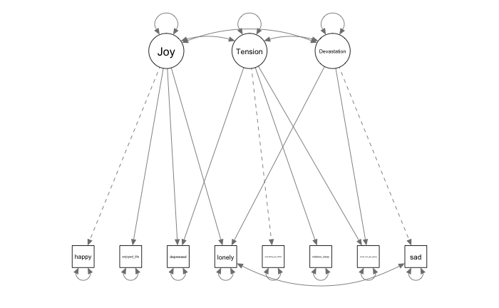

```r
library(semPlot)
 semPaths(cfa3.1, nCharNodes=0)
```

Построим диаграмму итоговой трехфакторной модели.

```r
fit.index<-data.frame(fitmeasures(cfa2),
           fitmeasures(cfa3),
           fitmeasures(cfa3.1)
           ) %>%
  set_colnames(c("Двухфакторная модель", "Трехфакторная модель", "Дополненная трехфакторная модель")) %>%
  extract(c("chisq", "df", "pvalue", "cfi", "tli", "rmsea", "bic"),)
knitr::kable(fit.index, digits=3, format="html")
```

|  | Двухфакторная модель | Трехфакторная модель | Дополненная трехфакторная модель |
| --- | --- | --- | --- |
| chisq | 406.364 | 96.444 | 13.184 |
| df | 19.000 | 17.000 | 13.000 |
| pvalue | 0.000 | 0.000 | 0.434 |
| cfi | 0.932 | 0.986 | 1.000 |
| tli | 0.900 | 0.977 | 1.000 |
| rmsea | 0.111 | 0.053 | 0.003 |
| bic | 25567.182 | 25272.094 | 25218.499 |

Выведем таблицу с индексами качества различных модификаций модели.

```r
tests <-lavTestLRT(cfa3, cfa3.1)
options(knitr.kable.NA = '')
knitr::kable(tests, format="html", digits=2)
```

|  | Df | AIC | BIC | Chisq | Chisq diff | Df diff | Pr(>Chisq) |
| --- | --- | --- | --- | --- | --- | --- | --- |
| cfa3.1 | 13 | 25093.92 | 25218.50 | 13.18 |  |  |  |
| cfa3 | 17 | 25169.18 | 25272.09 | 96.44 | 83.26 | 4 | 0 |

Тестирование различий в качестве трехфакторных моделей.

```r
with(cfa3.1@ParTable, data.frame(paste(lhs, op, rhs),
                                 round(est, 2),
                                 paste("(", round(se, 3), ")", sep="")
                                 )) %>%
  set_colnames(c("Параметр", "Значение", "Ст.ош.")) %>%
  knitr::kable(format="html", digits=2)
```

Параметр

Значение

Ст.ош.

Joy =~ happy

1.00

Joy =~ enjoyed_life

1.11

(0.045)

Tension =~ everything_as_effort

1.00

Tension =~ restless_sleep

0.80

(0.028)

Tension =~ depressed

0.85

(0.034)

Devastation =~ sad

1.00

Devastation =~ lonely

0.60

(0.051)

Devastation =~ could_not_get_going

0.89

(0.1)

Joy =~ lonely

-0.28

(0.044)

Joy =~ depressed

-0.12

(0.03)

Tension =~ could_not_get_going

0.19

(0.075)

sad ~~ lonely

0.03

(0.012)

happy ~~ happy

0.27

(0.017)

enjoyed_life ~~ enjoyed_life

0.22

(0.019)

everything_as_effort ~~ everything_as_effort

0.18

(0.011)

restless_sleep ~~ restless_sleep

0.28

(0.012)

depressed ~~ depressed

0.20

(0.01)

sad ~~ sad

0.18

(0.015)

lonely ~~ lonely

0.38

(0.016)

could_not_get_going ~~ could_not_get_going

0.21

(0.013)

Joy ~~ Joy

0.41

(0.026)

Tension ~~ Tension

0.42

(0.022)

Devastation ~~ Devastation

0.32

(0.021)

Joy ~~ Tension

-0.20

(0.015)

Joy ~~ Devastation

-0.24

(0.015)

Tension ~~ Devastation

0.28

(0.015)

Параметры итоговой модели.